# Sampling and custom stylo

Artjoms Šeļa

2023-02-12

For Day 1 we will look into some more manually driven stylo() function and some sampling strategies.

**DISCLAIMER.** This notebook uses base R and can be run just with `stylo()` installed. I never use base R in my work, though, and I don’t think base R is ‘simpler’ for beginners (it is the opposite, in fact). My further materials will utilize `tidyverse`, so you maybe would want to run `install.packages("tidyverse")` before Friday.

```r
## load library
library(stylo)
```

## Variables and attributes

We have a folder name that is not the default `corpus/` that stylo() look for by default. We can directly tell `stylo()` where to look for it.

We also save `stylo()` output to `res1` variable. ## R uses “<-” (shortcut: `shift + ctrl + —`) to assign values to variables, but `=` also works just fine (for most of the cases)!

```r
res1 <- stylo(gui=F, ## switch off GUI for now
              corpus.dir="corpus_carre/") ## custom directory
```

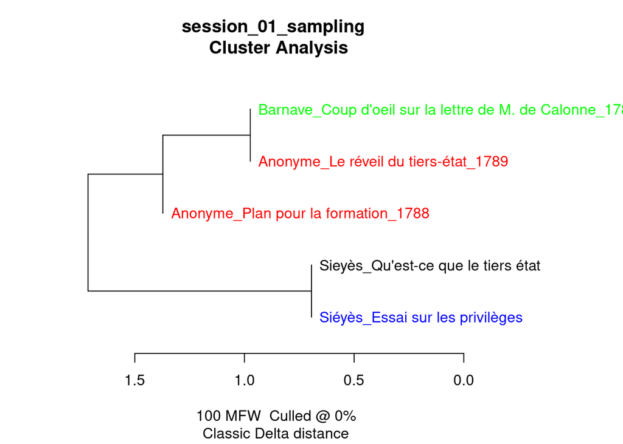

What is inside the results variable?

```r
summary(res1)
```

```
##
## Function call:
## stylo(gui = F, corpus.dir = "corpus_carre/")
##
## Available variables:
##
##            distance.table  final distances between each pair of samples
##                  features  features (e.g. words, n-grams, ...) applied to data
##    features.actually.used  features (e.g. frequent words) actually analyzed
##     frequencies.0.culling  frequencies of words/features accross the corpus
##             list.of.edges  edges of a network of stylometric similarities
##      table.with.all.freqs  frequencies of words/features accross the corpus
##    table.with.all.zscores  z-scored frequencies accross the corpus
##
## These variables can be accessed by typing e.g.:
##
##       res1$distance.table
```

Use `$` to access different parts of `res1`. `$` - is a special indexing operator in R for access to lists and tables.

```r
dt <- res1$distance.table ### e.g. distance table...
features <- res1$features.actually.used ### used features in the analysis...
freqs <- res1$frequencies.0.culling ### or document-term frequencies...
```

## Normal sampling

Normal sampling will chunk the texts sequentially by `sample.size` setting, striving for max number of samples available in each document.

```r
res_normal <- stylo(gui=F, ## no gui
              corpus.dir="corpus_carre/", ## custom directory
              analyzed.features = "w", ## a word is a token
              mfw.min = 100, ## max and min MFWs
              mfw.max = 100,
              sampling="normal.sampling",
              sample.size=2000,
              distance.measure="wurzburg", ## distance measure (wurzburg == cosine delta; i know, it is confusing)
              corpus.lang = "Other", ## corpus lang
              analysis.type="CA")  ## switch to MDS to see that CA might mislead interpretation
```

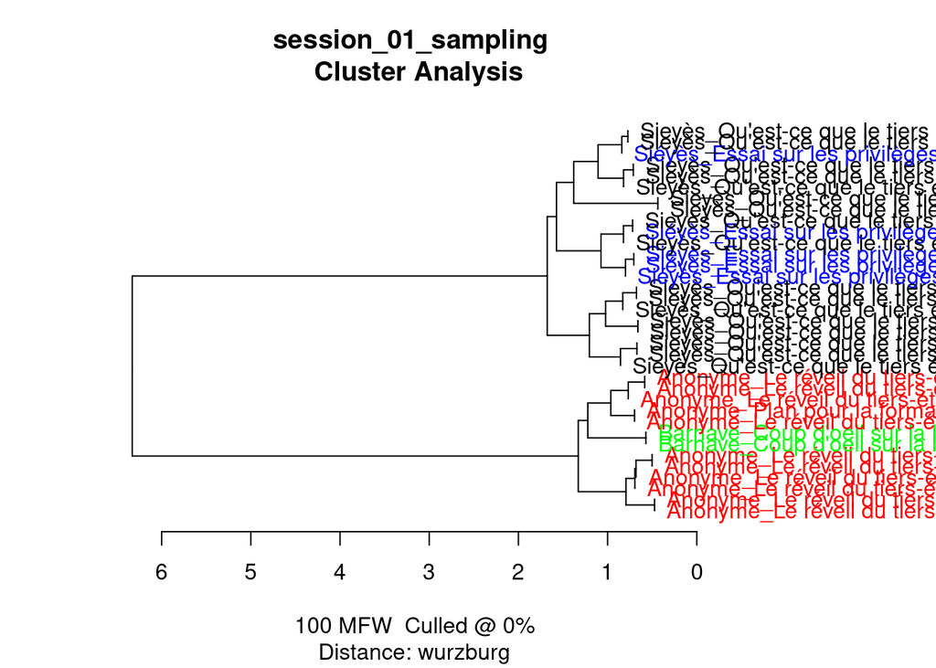

## Random sampling

Let’s now take 100 x 2000 words sample per each document. No text here is large enough to have 200k words, so we are actually reshuffling same information to see the extend of its distribution. One can also call it ‘bootstrapping’.

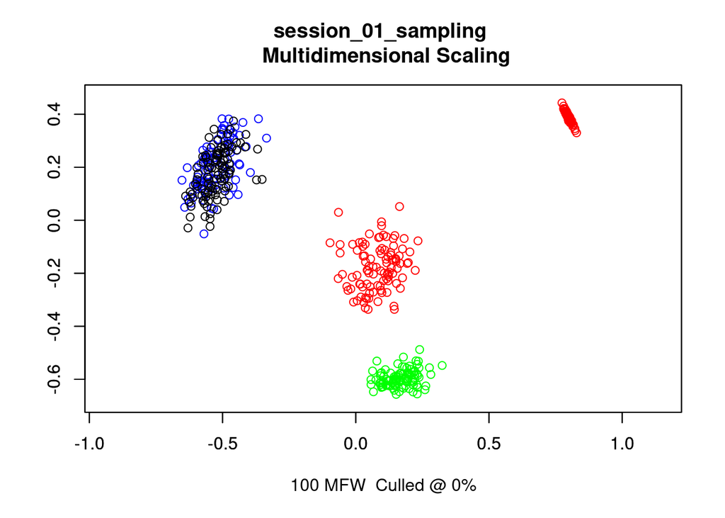

```r
res_rand <- stylo(gui=F, ## no gui
                  corpus.dir="corpus_carre/", ## custom directory
                  analyzed.features = "w", ## a word is a token
                  mfw.min = 100, ## max and min MFWs
                  mfw.max = 100,
                  sampling="random.sampling",
                  sample.size=2000,
                  number.of.samples = 100, ## 'bootstrapping` texts here, taking more than they can provide
                  distance.measure="wurzburg", ## distance measure (wurzburg == cosine delta; i know, it is confusing)
                  corpus.lang = "Other", ## corpus lang
                  text.id.on.graphs = "points", ## switch to points instead of labels
                  dump.samples = T, ## stylo will save samples in a folder
                  analysis.type="MDS")
```

## Custom frequencies, sample combinations

Now, let’s say you’d want to combine “bootstrapped” candidate authors and full (or normal-sampled) Anonymous. There are multiple ways to do it.

1. The easiest would be just to make a new folder, where we would combine different files. That, however, could be tedious and also poorly documented: you might forget the procedure and get lost in your folders. In code, this also looks awkward: e.g. where does this “combo” folder came up?? You remember it today, but tomorrow it would be a philological mystery to solve.

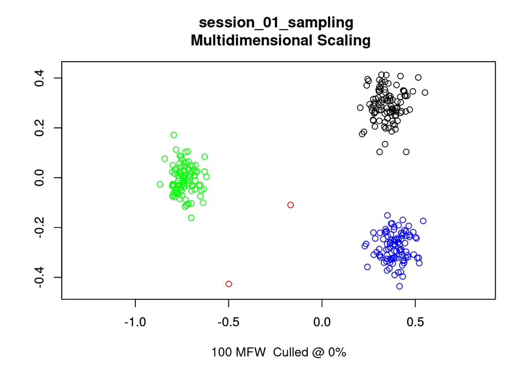

```r
res_combo1 <- stylo(gui=F,
                    corpus.dir="combo/",
                    analysis.type="MDS",
                    sampling="no.sampling",
                    text.id.on.graphs = "points"
                    )
```

2. Instead, we can combine frequencies of samples in R directly. In the end of the day, a set of numbers with labels is really what `stylo()` cares about. We have everything for it, because we saved all our results before, the only thing we need is to catch document names and combine everything in a new table.

```r
f_norm <- res_normal$frequencies.0.culling ## new variable with all frequencies from `normal sampling run'
rows_anon <- grep("^Anon", rownames(f_norm)) ## some regexp to catch all rows that start with (^) "Anon"

f_norm_anon <- f_norm[rows_anon,] ## subset the table only by rows that start with Anon
dim(f_norm_anon) ## 11 rows and 5000 columns (features, stylo's default cut off)
```

```
## [1]   11 5000
```

Now, to remove ‘Anonyme’ samples from our random sampling results. we can just use “-” (subract) to remove unwanted Anonyme rows.

```r
f_rand <- res_rand$frequencies.0.culling ## all random samples frequencies
rows_anon <- grep("^Anon", rownames(f_rand)) ## random Anonymous samples

f_clean <- f_rand[-rows_anon,] ## remove from random samples
```

Now, just combine the two tables with `rbind()` (bind rows).

```r
f_combo <- rbind(f_norm_anon, f_clean)
dim(f_combo) ## 311 x 5000 matrix.
```

```
## [1]  311 5000
```

Now, we have the data to directly inject it to `stylo()` analysis pipeline without preprocessing etc, by feeding the table to `frequencies=` attribute.

```r
res_combo2 <- stylo(gui=F, ## no gui
                    frequencies = f_combo, ## all you need for stylo to run, no actual raw corpus needed
                    mfw.min = 100, ## max and min MFWs
                    mfw.max = 100,
                    sampling="no.sampling",
                    distance.measure="wurzburg", ## distance measure (wurzburg == cosine delta; i know, it is confusing)
                    corpus.lang = "Other", ## corpus lang
                    analysis.type="CA")
```

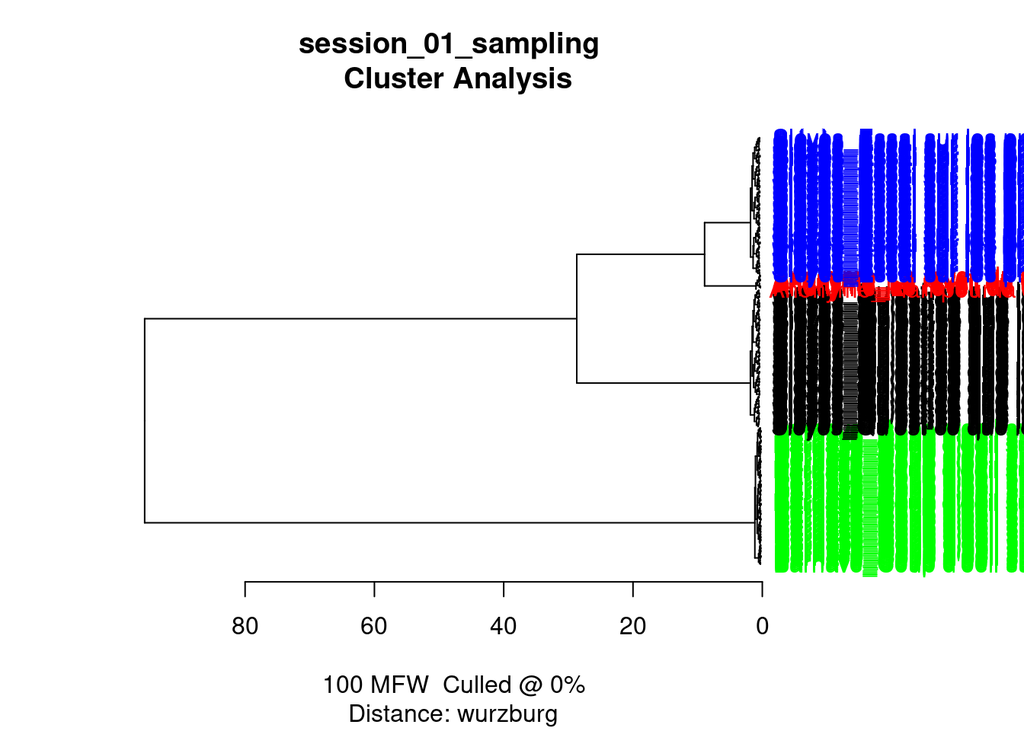

In the end, it combines Anonymous texts (normal sampled) with Sieyes (random sampled), providing a *very different picture* from before. **Mixing sampling strategies is bad idea!** As you see, everything can influence frequency distribution of features. Always good to be sceptical of pictures, you see how they can be easily manipulated.

## Comparing distances distributions

Let’s go back to oversampling strategy that we saved in `res_rand`. What we really are interested in is not what CA or MDS shows us, but overall patterns of similarity. You can approach it by looking at distances distributions directly. To demonstrate it, let’s make a bare-bones comparison of “different authors” vs. “same authors” distances from bootstrapped texts (because we have a lot of ‘estimates’ for between-sample distances).

First, let’s grab the distance table that is a square matrix that holds each pair-wise distance measurement in our corpus (since we had each of 5 texts sampled 100 times, it is a **500 x 500 matrix**)

```r
dists <- res_rand$distance.table ## saving distances in a new variable
dim(dists) ## number of rows x columns
```

```
## [1] 500 500
```

The key is to subset distance matrix by known authors and see how distances are distributed ‘wihin same author’ and ‘between different authors’ to establish some baseline of what we’re looking for.

```r
## distances within one author
bar <- grep("^Barnave", rownames(dists)) ## rows with Barnave
sie <- grep("^Siéyès", rownames(dists))  ## rows with Sieyes

d_b <- dists[bar,bar] ## barnave distances to barnave ('same author')
d_s <- dists[sie,sie] ## sieyes distances to sieyes ('same author')

d_other <- dists[bar,sie] ## barnave distances to sieyes ('different author')
```

Now, to plotting (base R plotting is a horror..)

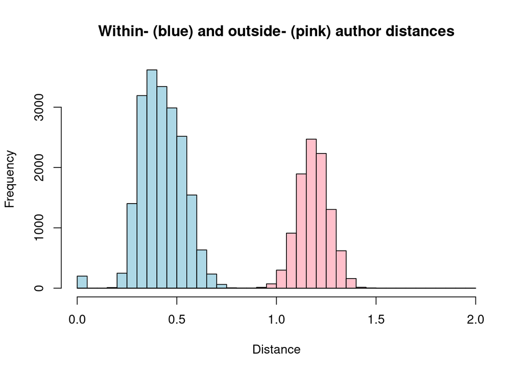

```r
hgA <- hist(c(d_b,d_s),  breaks = seq(0,2,by=0.05),plot = FALSE) # Save first histogram data
hgB <- hist(d_other, breaks=seq(0,2,by=0.05), plot = FALSE) # Save 2nd histogram data

plot(hgA, col = "lightblue",main="Within- (blue) and outside- (pink) author distances",xlab = "Distance") # Plot 1st histogram
plot(hgB, col = "pink", add = TRUE) # add 2nd histogram
```

Of course it is a toy example with two authors, but our method (100 MFWs, cosine distance) clearly catches the difference between ‘distances of the same hand’ and ‘distances between different hands’.

What we are left to do is just drop at these ‘two hills’ new data with the different behaviour of Anonymes.  
First, determining the rows and subsetting the distance matrix in various ways.

```r
anon1 <- grep("^Anonyme_Le", rownames(dists))
anon2 <- grep("^Anonyme_Plan",rownames(dists))

d_anon_in <- dists[anon1,anon2] ## distances between two Anonymes

d_anon1_b <- dists[anon1,bar] ## distances between Anonyme Le... and Barnave
d_anon1_s <- dists[anon1,sie] ## distances between Anonyme Le... and Sieyes
d_anon2_b <- dists[anon2,bar] ## distances between Anonyme Le... and Barnave
d_anon2_s <- dists[anon2,sie] ## distances between Anonyme Le... and Sieyes
```

### Anonyme ‘Le réveil…’ vs. Anonyme ‘Plan’

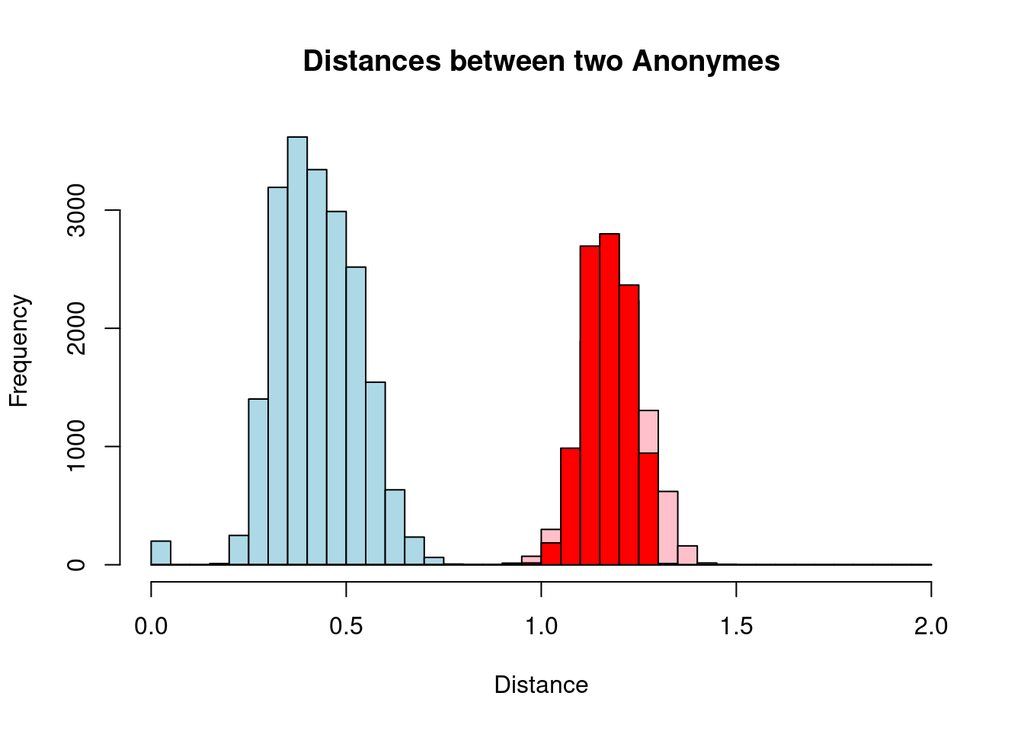

```r
hgC <- hist(d_anon_in, breaks=seq(0,2,by=0.05), plot = FALSE)

plot(hgA, col = "lightblue",main="Distances between two Anonymes",xlab = "Distance") # Plot 1st histogram
plot(hgB, col = "pink", add = TRUE) # add 2nd histogram
plot(hgC,col="red",add=TRUE) # add Anon vs Anon data
```

### Anonyme ‘Le réveil…’ vs. Barnave

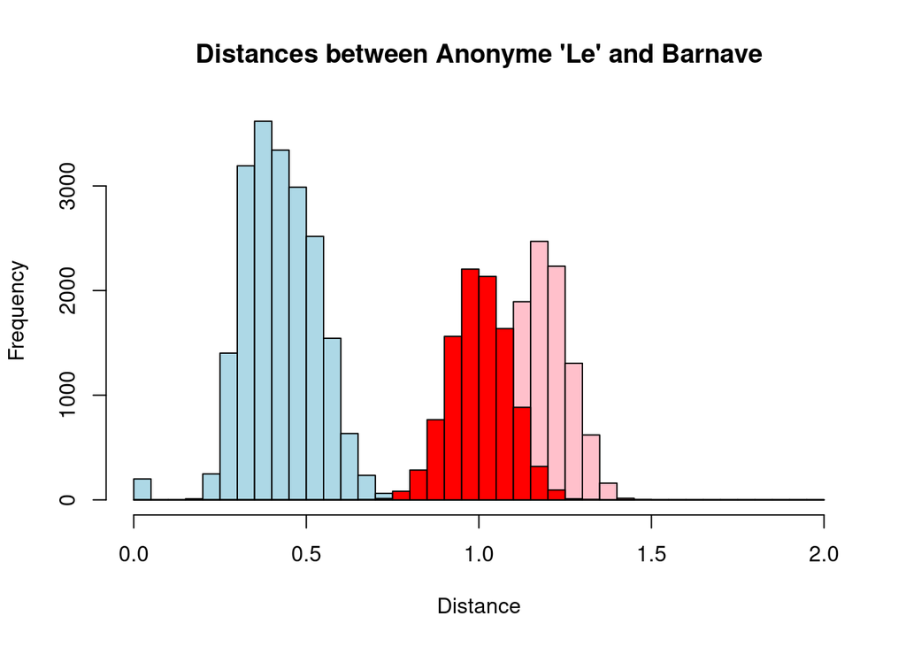

```r
hgC <- hist(d_anon1_b, breaks=seq(0,2,by=0.05), plot = FALSE)

plot(hgA, col = "lightblue",main="Distances between Anonyme 'Le' and Barnave",xlab = "Distance") # Plot 1st histogram
plot(hgB, col = "pink", add = TRUE) # add 2nd histogram
plot(hgC,col="red",add=TRUE)
```

### Anonyme ‘Le réveil…’ vs. Siéyès

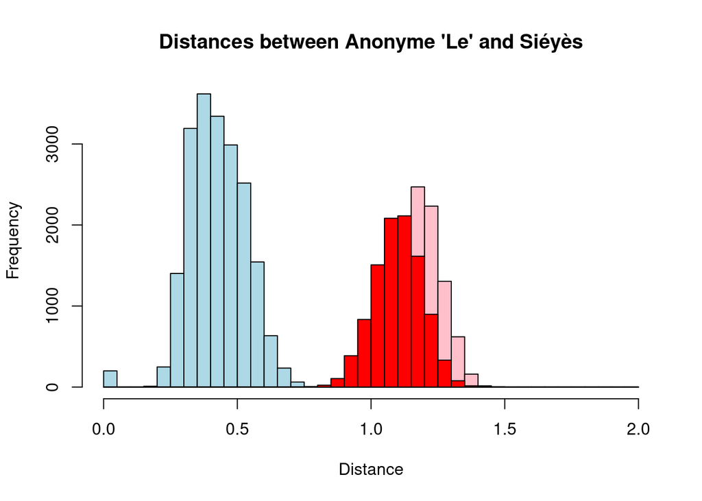

```r
hgC <- hist(d_anon1_s, breaks=seq(0,2,by=0.05), plot = FALSE)

plot(hgA, col = "lightblue",main="Distances between Anonyme 'Le' and Siéyès",xlab = "Distance") # Plot 1st histogram
plot(hgB, col = "pink", add = TRUE) # add 2nd histogram
plot(hgC,col="red",add=TRUE)
```

### Anonyme ‘Plan pour…’ vs. Barnave

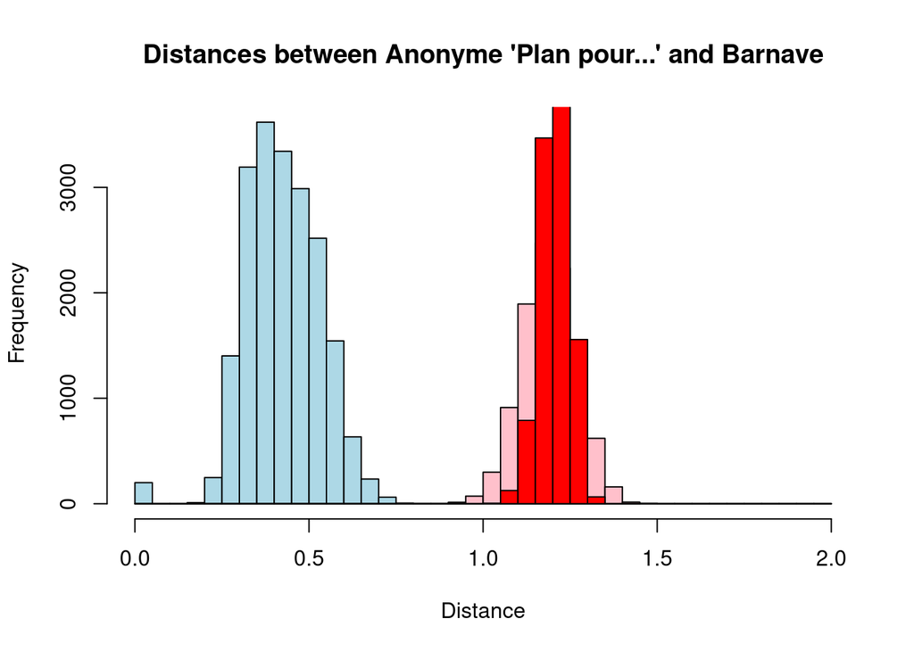

```r
hgC <- hist(d_anon2_b, breaks=seq(0,2,by=0.05), plot = FALSE)
plot(hgA, col = "lightblue",main="Distances between Anonyme 'Plan pour...' and Barnave",xlab = "Distance") # Plot 1st histogram
plot(hgB, col = "pink", add = TRUE) # add 2nd histogram
plot(hgC,col="red",add=TRUE)
```

### Anonyme ‘Plan pour…’ vs. Siéyès

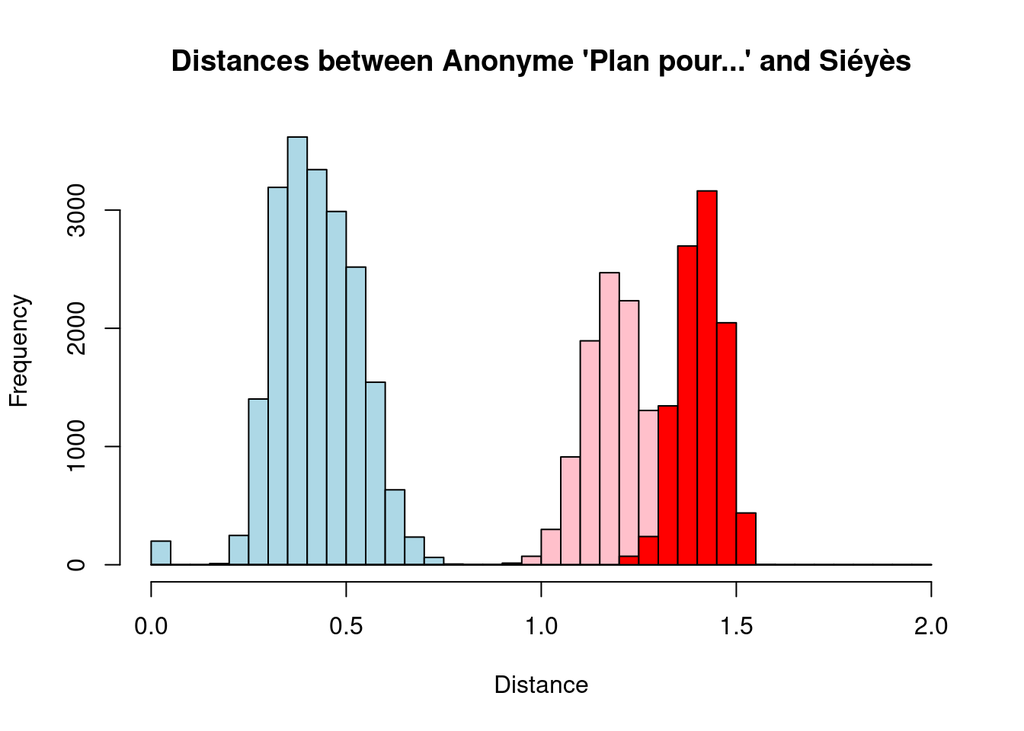

```r
hgC <- hist(d_anon2_s, breaks=seq(0,2,by=0.05), plot = FALSE)

plot(hgA, col = "lightblue",main="Distances between Anonyme 'Plan pour...' and Siéyès",xlab = "Distance") # Plot 1st histogram
plot(hgB, col = "pink", add = TRUE) # add 2nd histogram
plot(hgC,col="red",add=TRUE)
```

A lesson here? Given the *very* limited scope of the data, if Barnave and Siéyès were the two candidate authors, it is likely that none of them authored Anonymous texts. It is also unlikely that two Anonymous texts come from the same author (**given the data!**).